# Canada Mortgage Delinquency: Unemployment, the Policy Rate and Out-of-Sample Validation

Author

Luis Alonso Alvarez Portugal

Published

November 18, 2026

# Summary

The mortgage delinquency in Canada is closely tied to unemployment. Across 10 provinces, one more percentage point of unemployment goes with about 19% higher delinquency, and a panel of 33 metropolitan areas gives a similar figure (about 17%). Much of this relationship disappears when provinces are compared within the same quarter, so part of it reflects shocks shared across the country. The policy rate effect cannot be identified, because the sample covers a single large cycle. Delinquency changes slowly, so next quarter is hard to predict better than with last quarter’s value: The best model, a random forest fitted to quarterly changes, cuts the error by 8%, but the gain is not statistically significant (p = 0.13).

# Data

The panel covers 10 provinces and 54 quarters, from 2012Q3 to 2025Q4 (540 province-quarters). The CMHC data used here was published in March 2026.

*[Sources: CMHC delinquency, Labour Force Survey unemployment, Bank of Canada policy rate.]*

Delinquency by province (descriptive statistics)

| province | delinq_mean | delinq_min | delinq_max | unemp_mean | unemp_min | unemp_max |
| --- | --- | --- | --- | --- | --- | --- |
| New Brunswick | 0.52 | 0.21 | 0.84 | 8.76 | 6.37 | 13.27 |
| Saskatchewan | 0.52 | 0.30 | 0.75 | 5.56 | 3.73 | 11.50 |
| Nova Scotia | 0.47 | 0.20 | 0.76 | 8.07 | 5.73 | 13.73 |
| Newfoundland | 0.42 | 0.19 | 0.68 | 12.39 | 9.03 | 17.03 |
| Alberta | 0.41 | 0.25 | 0.60 | 6.93 | 4.53 | 14.60 |
| Prince Edward Island | 0.38 | 0.11 | 0.70 | 9.61 | 6.43 | 13.50 |
| Québec | 0.30 | 0.12 | 0.44 | 6.35 | 3.97 | 14.47 |
| Manitoba | 0.28 | 0.20 | 0.37 | 5.74 | 4.40 | 11.30 |
| British Columbia | 0.23 | 0.10 | 0.43 | 5.98 | 4.40 | 12.90 |
| Ontario | 0.18 | 0.07 | 0.31 | 6.93 | 5.27 | 12.97 |

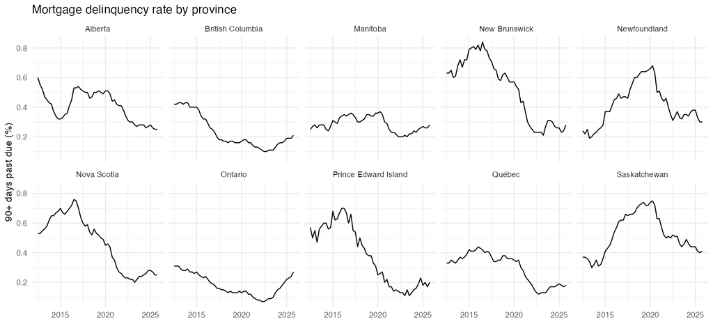

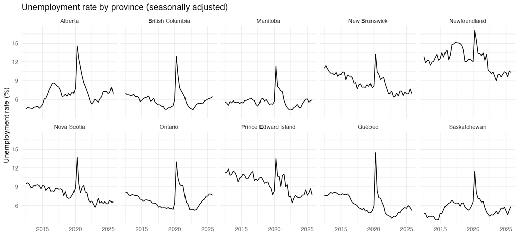

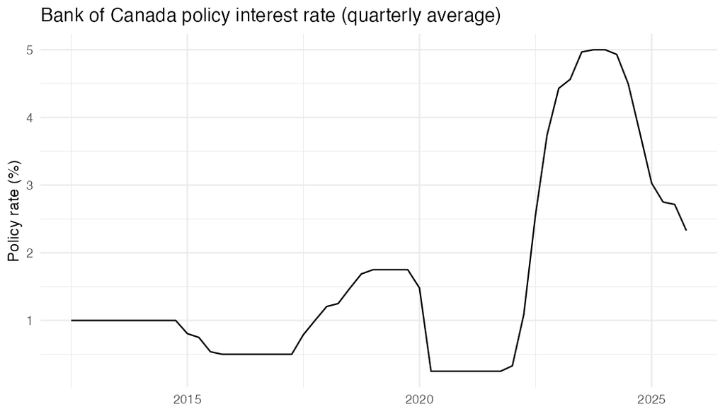

# Methods

## Why a panel with fixed effects

Provinces differ permanently in ways I cannot observe or measure well, such as housing market structure, lending practices and demographics. Province fixed effects remove these constant differences, so the model compares each province with itself over time: what happens to delinquency in a province when its unemployment changes. This removes omitted variables that are constant within a province, but not those that change over time, which I discuss in the next section. Quarter-of-year effects absorb seasonality. I do not include a full set of date effects, because they would absorb the national policy rate, which only varies over time.

## Omitted variable bias

A fixed effects model adds a dummy variable for each province. These dummies control for any characteristic, observed or not, that is constant within a province over time. They do not control for factors that change over time within a province and move with unemployment, such as local income or house prices. If such factors exist, the unemployment coefficient is biased, and I cannot say in which direction. It as an association, not as a causal effect. The robustness checks show how much of the association is shared across places: in the metropolitan-area models, the coefficient falls from 0.154 to 0.093 when I remove shocks common to all areas in a quarter, and to 0.034 when I compare areas within the same province and quarter. Part of the association reflects common shocks.

## COVID

The COVID period was atypical: payment deferrals and income support likely pushed delinquency down while unemployment spiked, which broke the usual relationship between the two. I set these quarters apart with an indicator for 2020Q2 to 2021Q4. In the main model, the indicator is about -0.50, meaning delinquency was roughly 40% lower in those quarters than unemployment and the policy rate would predict. I also estimate the model without those quarters, and the unemployment coefficient rises from 0.171 to 0.228.

## Inference

I cluster standard errors by province, but 10 clusters is too few to trust them fully, so I treat the intervals as indicative. As a check, I repeat the models on 33 metropolitan areas. The results are similar (0.154 against 0.171), though areas in the same province share shocks, so these standard errors are probably too small.

## Out-of-sample validation

The baseline model is a panel regression with province and quarter-of-year fixed effects, used to measure the association between unemployment, the policy rate and delinquency. To see whether a more flexible model predicts better, I also fit random forests (500 trees, no tuning), which do not assume a functional form and can capture nonlinear effects.

There is a comparison of all models on quarters they were not fitted on. For each of the 16 test quarters (2022Q1 to 2025Q4), I refit every model on all earlier data and predict one quarter ahead, which gives 160 predictions per model. The reference is a model that only uses last quarter’s delinquency, and I measure error as RMSE in log points. To test whether differences between models are real, a Diebold-Mariano is performed to test on the average error per quarter. As there are only 16 test quarters the test has low power.

## Scenarios

The scenarios are conditional projections from the persistence plus unemployment model, not forecasts. Starting in 2025Q4, unemployment rises by 0 (baseline), 2 (moderate stress) or 4 (severe stress) percentage points over four quarters and then stays fixed, for a horizon of 8 quarters, with the COVID indicator off. These results are simple averages across provinces, not weighted by number of mortgages, and have no uncertainty bands.

# Results

## Association with unemployment and the policy rate

Unemployment is associated with delinquency in all specifications. In the main model, one more percentage point of unemployment goes with about 19% higher delinquency (coefficient 0.171). The policy rate is negative at every lag, the opposite of the expected sign. It is significant at two quarters (p = 0.009 and 0.029), borderline at four (p = 0.053), and not significant without the COVID quarters (p = 0.144). The figure shows the coefficient by lag: it is negative throughout, and the intervals include zero at lags 4 to 8. With a single rate cycle, it is not possible to split the effect of the policy rate from other things that changed between 2022 and 2025. Also, the delinquency is persistent (last quarter’s delinquency in the model, its coefficient is 0.955, the short-run effect of unemployment falls to 0.011 and the implied long-run effect is 0.245).

Provincial fixed-effects models. Coefficient (standard error).

| term | m1 | m2 | m3 | m4 | m5 | m6 |
| --- | --- | --- | --- | --- | --- | --- |
| Unemployment (same quarter) | 0.167 (0.035) | 0.119 (0.023) |  |  |  |  |
| Policy rate (2-quarter lag) | -0.078 (0.024) | -0.065 (0.025) |  |  |  |  |
| COVID indicator | -0.548 (0.161) | -0.594 (0.170) | -0.501 (0.152) |  |  | -0.087 (0.011) |
| Unemployment (1-quarter lag) |  | 0.076 (0.021) | 0.171 (0.036) | 0.228 (0.052) | 0.148 (0.044) | 0.011 (0.003) |
| Policy rate (4-quarter lag) |  |  | -0.047 (0.021) | -0.038 (0.024) |  |  |
| Last quarter’s delinquency (log) |  |  |  |  |  | 0.955 (0.009) |

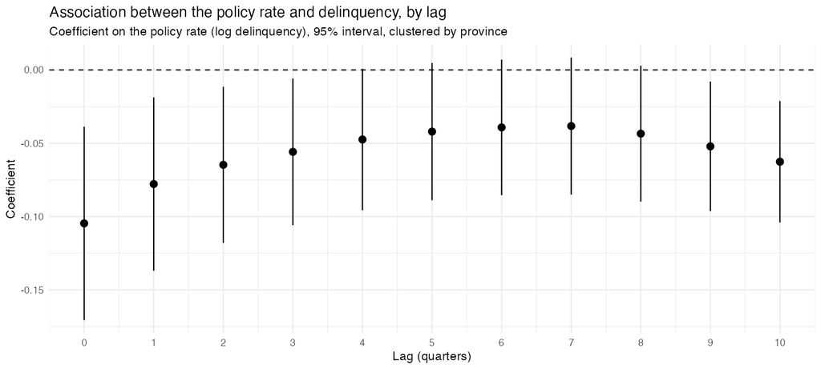

m1 and m2 include the policy rate at a 2-quarter lag, and m3 at a 4-quarter lag. m4 is m3 without the COVID quarters. m5 uses date fixed effects. m6 adds last quarter’s delinquency.

## Robustness with 33 metropolitan areas

The metropolitan-area results are close to the provincial ones. The unemployment coefficient is 0.154 in the main model (0.171 for provinces) and 0.215 without the COVID quarters (0.228). It falls to 0.093 with date effects (0.148) and to 0.034 when areas are compared within the same province and quarter, where it is only significant at 10% (p = 0.086). With last quarter’s delinquency in the model, persistence is 0.932 and the short-run effect of unemployment is 0.013. The association persists in the city data, but a large part of it is shared across areas at the same time. The standard errors are small because there are many areas and quarters. But the observations are not independent: delinquency changes slowly, and areas in the same province move together. It is important to say that the uncertainty is larger than the standard errors suggest.

Metropolitan-area models. Coefficient (standard error).

| term | c1 | c2 | c3 | c4 | c5 | c6 |
| --- | --- | --- | --- | --- | --- | --- |
| Unemployment (1-quarter lag) | 0.154 (0.016) | 0.154 (0.021) | 0.215 (0.026) | 0.093 (0.025) | 0.034 (0.019) | 0.013 (0.003) |
| Policy rate (4-quarter lag) | -0.048 (0.016) | -0.048 (0.031) | -0.049 (0.016) |  |  |  |
| COVID indicator | -0.651 (0.086) | -0.651 (0.171) |  |  |  | -0.110 (0.013) |
| Last quarter’s delinquency (log) |  |  |  |  |  | 0.932 (0.007) |

c1 and c2 are the main model, with standard errors clustered by metropolitan area (c1) and by province (c2). c3 excludes the COVID quarters. c4 uses date fixed effects and c5 province-by-date fixed effects. c6 adds last quarter’s delinquency.

## Heterogeneity by province

Unemployment is positive in all provinces. In the provincial panel it ranges from 0.09 (Alberta) to 0.30 (Prince Edward Island), and in the metropolitan-area panel from 0.09 (Alberta) to 0.23 (British Columbia). British Columbia in the provincial panel has a lower bound just below zero (-0.001). Each estimate uses about 50 quarters of a highly persistent series, and metropolitan areas within a province are not independent. I therefore treat the intervals as indicative and do not rank provinces.

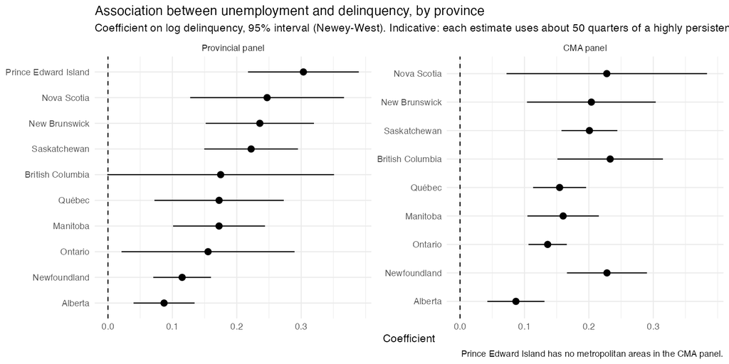

## Prediction

Next quarter’s delinquency is mostly predicted by this quarter’s. A model that only uses that already does about as well as the others. Adding unemployment or the policy rate barely improves it: the average error falls from 0.096 to 0.094 and 0.093 log points. The best result comes from a random forest, which cuts the error by 8%. It beats the simple model in 13 of 16 quarters, but with so few quarters the gain cannot be told apart from chance (p = 0.13). Also, the models that leave out last quarter’s delinquency do much worse and all of them underestimated delinquency in the second half of 2023.

Out-of-sample error, 16 test quarters. Log points.

| Model | MSE | RMSE | MAE |
| --- | --- | --- | --- |
| Random forest (change) | 0.0079 | 0.0887 | 0.0653 |
| Persistence + unemployment + policy rate | 0.0087 | 0.0931 | 0.0719 |
| Last-quarter benchmark | 0.0087 | 0.0934 | 0.0694 |
| Persistence + unemployment | 0.0088 | 0.0940 | 0.0704 |
| Persistence only (baseline) | 0.0093 | 0.0964 | 0.0712 |
| Random forest (level) | 0.0182 | 0.1350 | 0.0961 |
| Economy only | 0.2054 | 0.4532 | 0.3808 |

Diebold-Mariano test against the persistence-only baseline (squared error). Positive differences mean lower error than the baseline.

| Model | Quarters better than baseline (of 16) | Mean loss difference | DM statistic | p-value |
| --- | --- | --- | --- | --- |
| Economy only | 0 | -0.196 | -5.471 | <0.001 |
| Random forest (level) | 4 | -0.009 | -2.057 | 0.058 |
| Random forest (change) | 13 | 0.001 | 1.596 | 0.131 |
| Persistence + unemployment | 11 | 0.000 | 1.108 | 0.285 |
| Last-quarter benchmark | 9 | 0.001 | 0.748 | 0.466 |
| Persistence + unemployment + policy rate | 8 | 0.001 | 0.543 | 0.595 |

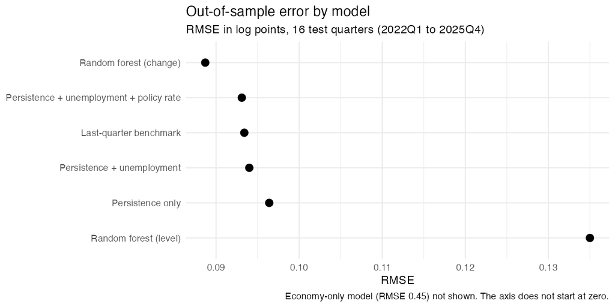

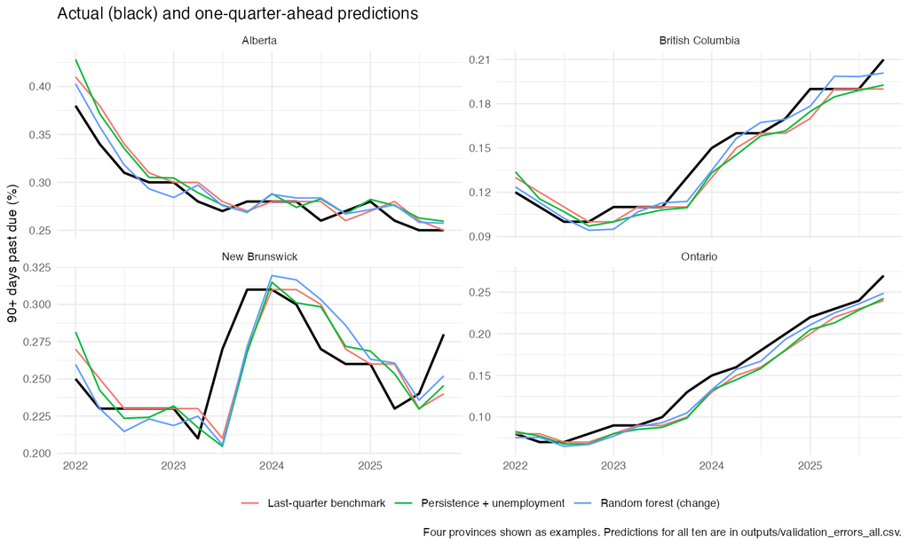

## Scenarios

Average delinquency at the end of the 8-quarter horizon.

| Scenario | Average delinquency (%) |
| --- | --- |
| Baseline | 0.278 |
| Moderate stress | 0.309 |
| Severe stress | 0.345 |

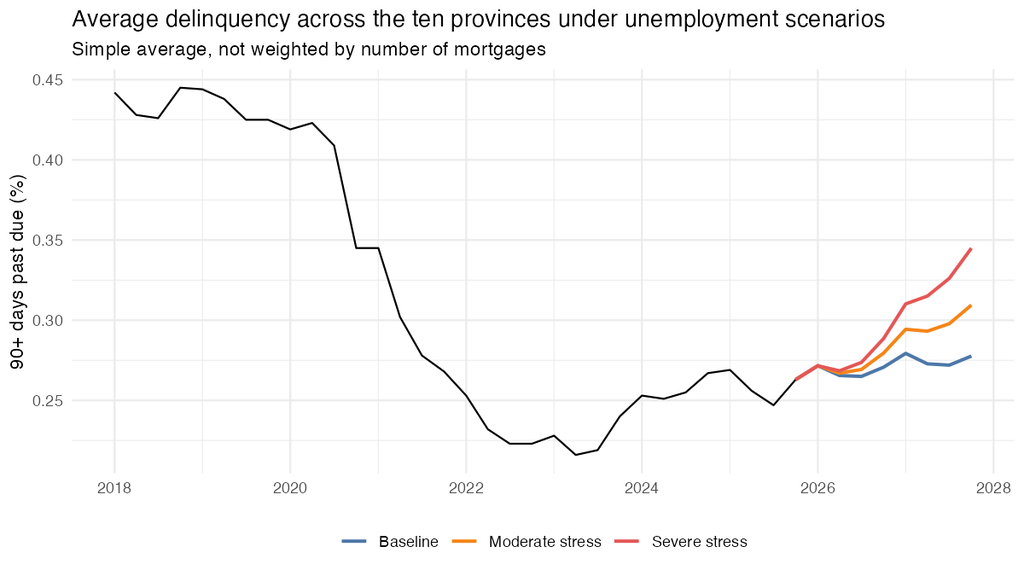

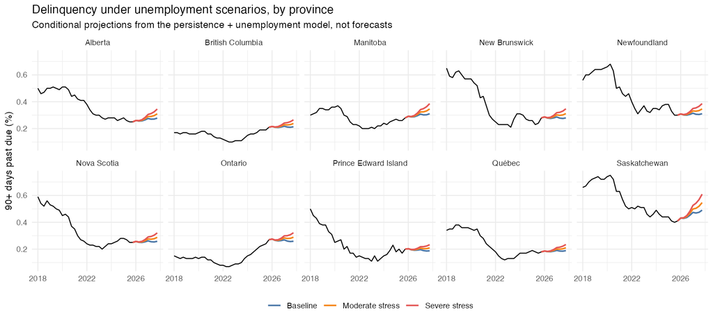

## v2: Adding house prices

### Data

I added the Statistics Canada New Housing Price Index (table 18-10-0205-01) to the panel. The variable is quarterly year-over-year growth by province, entered at lags of 0, 1, 2 and 4 quarters.

### Lag profile

House price growth is negatively associated with delinquency at every lag, and all four coefficients are significant (p < 0.001). The effect grows with the lag, from -0.036 at lag 0 to -0.060 at four quarters. House price changes take about a year to show up fully in delinquency.

### Models with and without house prices

All models explain the log delinquency rate, with province fixed effects and standard errors clustered by province.

- **Specification a:** unemployment (1-quarter lag), interest rate (4-quarter lag) and a covid indicator, with quarter fixed effects.
- **Specification b:** unemployment (1-quarter lag) only, with a fixed effect for every date. It uses only differences across provinces, so it is the strictest test.
- **Specification c:** adds last quarter’s delinquency as a regressor, alongside unemployment and the covid indicator.

Adding house prices reduces the unemployment coefficient by 27% (a), 11% (b) and 33% (c). Part of what unemployment appeared to explain was house prices. House prices are significant in specifications a and c (p < 0.001) but not in b (p = 0.18).

Variance inflation factors (VIF) for the regressors are all below 5 (house price growth 1.6, interest rate 1.3, covid indicator 1.7). Unemployment is the highest at 4.7, which matches its coefficient shrinking when house prices are added.

Also, residual diagnostics show no strong departures from normality or constant variance.

### Out-of-sample validation with house prices

| Model | Root mean squared error | Change vs. baseline |
| --- | --- | --- |
| Autoregressive baseline | 0.0964 |  |
| Baseline + macro variables | 0.0940 | -2.5% |
| Baseline + macro variables + house prices | 0.0832 | -13.7% |

The house price model beats the baseline (Diebold-Mariano p = 0.005, better in 13 quarters) and the macro-only model (p = 0.0052, better in 12 quarters).

The v2 house price result is predictive, not causal. Standard errors are clustered by province, and there are only ten provinces, so p-values should be read with caution.

# Limitations

- The estimates are associations. Factors that move with unemployment, such as local income losses or house prices, can bias them. With province-by-date effects the coefficient falls from 0.154 to 0.034, so much of the link is shared across provinces.
- The sample has one large rate cycle, so the effect of the policy rate cannot be identified. The policy rate is also not the mortgage rate that borrowers pay.
- Ten provinces are too few for reliable standard errors. The 33-area panel helps, but metropolitan unemployment comes from a survey with more sampling noise, which likely pulls coefficients toward zero.
- Ontario has 15 of the 33 metropolitan areas, so it weighs heavily in the pooled results.
- The long-run effect depends on persistence close to one (0.955) and is fragile.
- Validation uses only 16 test quarters. The test has low power, so a non-significant result does not mean the models are equal. The random forests were not tuned.
- The scenarios have no uncertainty bands and use a simple average across provinces, not one weighted by portfolio size.

# Conclusions

Unemployment is closely tied to mortgage delinquency in Canada, both across provinces and across metropolitan areas. When provinces are compared within the same quarter, a weaker relationship remains, so much of the link comes from shocks that hit the whole country at once. The effect of the policy rate cannot be identified, because the data cover only one rate cycle. Delinquency moves slowly. That makes it hard to beat last quarter’s value as a prediction, and hard to learn what drives it from a short panel.